# Case Study 1- DS 6306

2024-03-08

# Introduction

We have undertaken a comprehensive analysis of two important datasets that provide a detailed snapshot of the brewing industry. The first dataset encapsulates a wealth of information on 2,410 U.S. craft beers, covering aspects such as their alcohol by volume (ABV), International Bitterness Units (IBUs), and beer style. This data offers valuable insights into the popularity of various beer styles, the correlation between ABV and IBUs, and potential market trends. The second dataset provides records on 558 U.S. breweries, including their location and size. This dataset will allow us to understand geographical distribution, market saturation, and opportunities for expansion. By cross-referencing these datasets, we can identify patterns and trends that could inform Budweiser’s strategic decisions. Our goal is to present these findings in a clear and impactful manner, focusing on the implications of the data rather than the technicalities of the analysis. We trust that these insights will contribute significantly to shaping Budweiser’s future strategies. Thank you for your time, and we look forward to discussing our findings with you.

```r
#Import and name each data set
beers <- read.csv("https://github.com/torih1541/Case-Study-1-DDS/files/14513428/Beers.csv")
breweries <- read.csv("https://github.com/torih1541/Case-Study-1-DDS/files/14513429/Breweries.csv")
```

#### How many breweries are present in each state?

The number of breweries present in each state, sorted by the states with the most breweries: Colorado (CO) - 47 breweries, California (CA) - 39 breweries, Michigan (MI) - 32 breweries, Oregon (OR) - 29 breweries, Texas (TX) - 28 breweries. The list continues with states having fewer breweries, all the way down to those with just one brewery, such as North Dakota (ND), South Dakota (SD), Washington D.C. (DC), and West Virginia (WV).  
This list and map shows a strong presence of breweries in certain states, reflecting perhaps a robust craft beer culture in those locations.

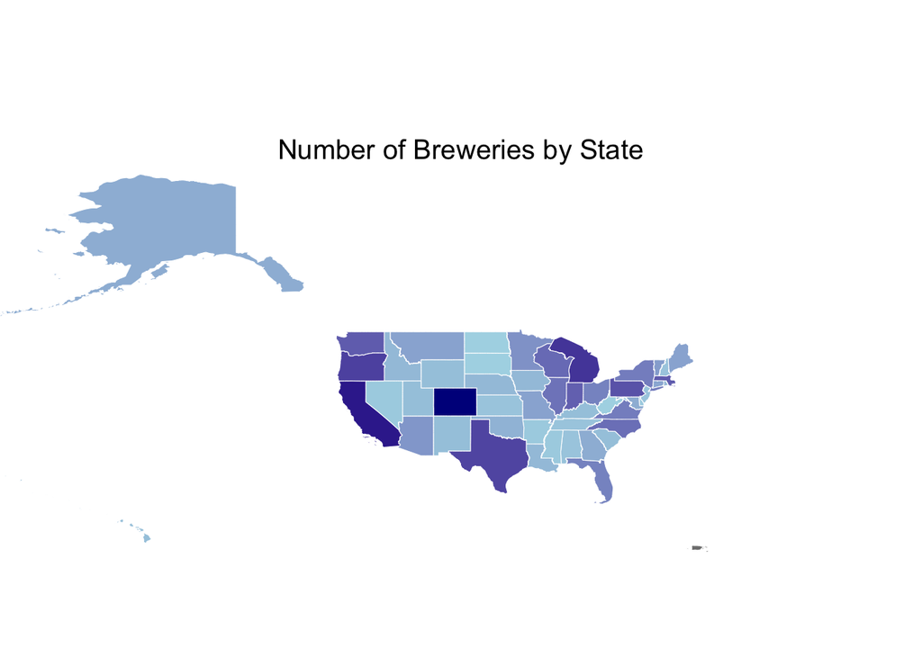

```r
#Map state abbreviations to their full names
state_map <- c(
  "AL" = "Alabama", AK = "Alaska", AZ = "Arizona", AR = "Arkansas", CA = "California",
  CO = "Colorado", CT = "Connecticut", DE = "Delaware", FL = "Florida", GA = "Georgia",
  HI = "Hawaii", ID = "Idaho", IL = "Illinois", IN = "Indiana", IA = "Iowa",
  KS = "Kansas", KY = "Kentucky", LA = "Louisiana", ME = "Maine", MD = "Maryland",
  MA = "Massachusetts", MI = "Michigan", "MN" = "Minnesota", MS = "Mississippi", MO = "Missouri",
  MT = "Montana", NE = "Nebraska", NV = "Nevada", NH = "New Hampshire", NJ = "New Jersey",
  NM = "New Mexico", NY = "New York", NC = "North Carolina", ND = "North Dakota", OH = "Ohio",
  OK = "Oklahoma", OR = "Oregon", PA = "Pennsylvania", RI = "Rhode Island", SC = "South Carolina",
  SD = "South Dakota", TN = "Tennessee", TX = "Texas", UT = "Utah", VT = "Vermont",
  VA = "Virginia", WA = "Washington", WV = "West Virginia", WI = "Wisconsin", WY = "Wyoming"
)

#Prepare breweries dataset
breweries <- breweries %>%
  mutate(State = str_trim(State),
         State = toupper(State),
         StateFullName = state_map[State])

#Aggregate and count number of breweries by state
breweries_by_state <- breweries %>%
  group_by(StateFullName) %>%
  summarise(NumberOfBreweries = n())

#Load US states shapefile for mapping
us_states <- st_read("tl_2023_us_state/tl_2023_us_state.shp")
#Merge the shapefile data with count data
map_data1 <- merge(us_states, breweries_by_state, by.x= "NAME", by.y= "StateFullName", all.x = TRUE)

#Create a map of the nummber of breweries by state
ggplot(data = map_data1) +
  geom_sf(aes(fill = NumberOfBreweries), color = "white") +
  scale_fill_gradient(low = "lightblue", high = "darkblue", name = "Number of Breweries") +
  labs(title = "Number of Breweries by State", x = "", y = "") +
  theme_minimal() +
  theme(plot.title = element_text(hjust = 0.15,size = 15),
        axis.text = element_blank(),
        axis.title = element_blank(),
        panel.grid = element_blank(),
        panel.background = element_rect(color="white"),
        legend.position = 'none',
        plot.margin = unit(c(0, -25, -5, 0), "cm"),
        plot.background = element_rect(color = "white")
        ) +
        coord_sf(expand= FALSE, datum = NA)
```

#### Merge beer data with the breweries data. Print the first 6 observations and the last six observations to check the merged file.

```r
# Merge the data frames on the Brewery_id (in beers) and Brew_id (in breweries)
merged_data <- merge(beers, breweries, by.x = "Brewery_id", by.y = "Brew_ID")

# Print the first 6 observations
print(head(merged_data, 6))
```

```
##   Brewery_id        Name.x Beer_ID   ABV IBU
## 1          1  Get Together    2692 0.045  50
## 2          1 Maggie's Leap    2691 0.049  26
## 3          1    Wall's End    2690 0.048  19
## 4          1       Pumpion    2689 0.060  38
## 5          1    Stronghold    2688 0.060  25
## 6          1   Parapet ESB    2687 0.056  47
##                                 Style Ounces             Name.y        City
## 1                        American IPA     16 NorthGate Brewing  Minneapolis
## 2                  Milk / Sweet Stout     16 NorthGate Brewing  Minneapolis
## 3                   English Brown Ale     16 NorthGate Brewing  Minneapolis
## 4                         Pumpkin Ale     16 NorthGate Brewing  Minneapolis
## 5                     American Porter     16 NorthGate Brewing  Minneapolis
## 6 Extra Special / Strong Bitter (ESB)     16 NorthGate Brewing  Minneapolis
##   State StateFullName
## 1    MN     Minnesota
## 2    MN     Minnesota
## 3    MN     Minnesota
## 4    MN     Minnesota
## 5    MN     Minnesota
## 6    MN     Minnesota
```

```r
# Print the last 6 observations
print(tail(merged_data, 6))
```

```
##      Brewery_id                    Name.x Beer_ID   ABV IBU
## 2405        556             Pilsner Ukiah      98 0.055  NA
## 2406        557  Heinnieweisse Weissebier      52 0.049  NA
## 2407        557           Snapperhead IPA      51 0.068  NA
## 2408        557         Moo Thunder Stout      50 0.049  NA
## 2409        557         Porkslap Pale Ale      49 0.043  NA
## 2410        558 Urban Wilderness Pale Ale      30 0.049  NA
##                        Style Ounces                        Name.y          City
## 2405         German Pilsener     12         Ukiah Brewing Company         Ukiah
## 2406              Hefeweizen     12       Butternuts Beer and Ale Garrattsville
## 2407            American IPA     12       Butternuts Beer and Ale Garrattsville
## 2408      Milk / Sweet Stout     12       Butternuts Beer and Ale Garrattsville
## 2409 American Pale Ale (APA)     12       Butternuts Beer and Ale Garrattsville
## 2410        English Pale Ale     12 Sleeping Lady Brewing Company     Anchorage
##      State StateFullName
## 2405    CA    California
## 2406    NY      New York
## 2407    NY      New York
## 2408    NY      New York
## 2409    NY      New York
## 2410    AK        Alaska
```

#### Address the missing values in each column.

The missing ABV values could be missing if the brewery did not or chose not to measure ABV values for some beers and there does not seem to be certain types of beer more likely to be missing ABV so these are missing at random. The large number of missing IBU values could suggest measuring IBU is too expensive or time consuming so breweries would choose not to measure this leaving the values missing at random. We used MCAR test to create a heat map of the data missingness to determine patterns.

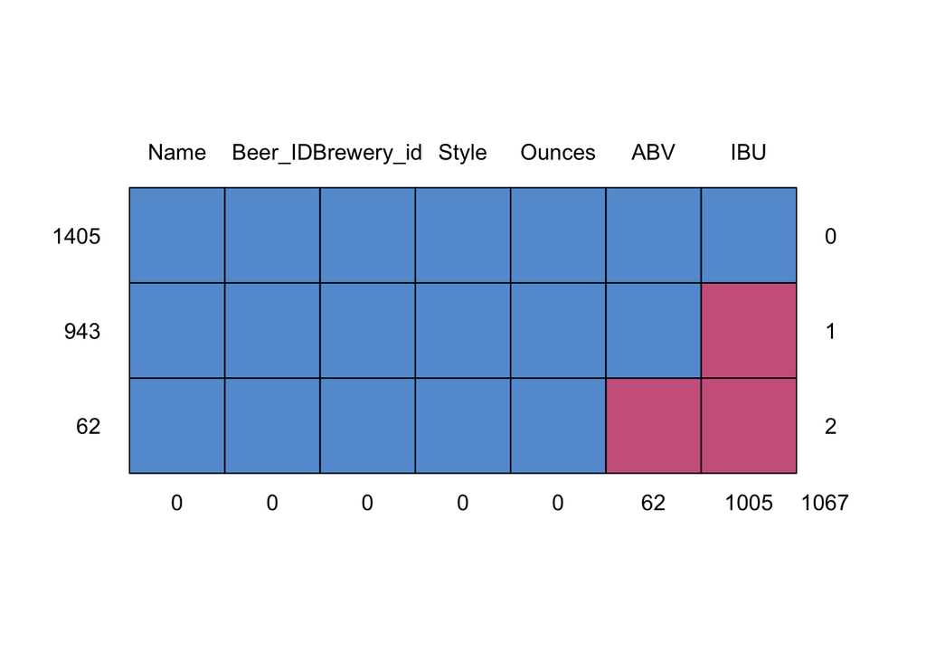

```r
# Little's MCAR test
mcar_test <- mice::md.pattern(beers)
```

```r
summary(merged_data)
```

```
##    Brewery_id       Name.x             Beer_ID            ABV
##  Min.   :  1.0   Length:2410        Min.   :   1.0   Min.   :0.00100
##  1st Qu.: 94.0   Class :character   1st Qu.: 808.2   1st Qu.:0.05000
##  Median :206.0   Mode  :character   Median :1453.5   Median :0.05600
##  Mean   :232.7                      Mean   :1431.1   Mean   :0.05977
##  3rd Qu.:367.0                      3rd Qu.:2075.8   3rd Qu.:0.06700
##  Max.   :558.0                      Max.   :2692.0   Max.   :0.12800
##                                                      NA's   :62
##       IBU            Style               Ounces         Name.y
##  Min.   :  4.00   Length:2410        Min.   : 8.40   Length:2410
##  1st Qu.: 21.00   Class :character   1st Qu.:12.00   Class :character
##  Median : 35.00   Mode  :character   Median :12.00   Mode  :character
##  Mean   : 42.71                      Mean   :13.59
##  3rd Qu.: 64.00                      3rd Qu.:16.00
##  Max.   :138.00                      Max.   :32.00
##  NA's   :1005
##      City              State           StateFullName
##  Length:2410        Length:2410        Length:2410
##  Class :character   Class :character   Class :character
##  Mode  :character   Mode  :character   Mode  :character
##
##
##
##
```

```r
#Create dataframe with no NA values to perform further analysis
cleaned_data <- na.omit(merged_data)

# Print the first 6 observations
print(head(cleaned_data, 6))
```

```
##   Brewery_id        Name.x Beer_ID   ABV IBU
## 1          1  Get Together    2692 0.045  50
## 2          1 Maggie's Leap    2691 0.049  26
## 3          1    Wall's End    2690 0.048  19
## 4          1       Pumpion    2689 0.060  38
## 5          1    Stronghold    2688 0.060  25
## 6          1   Parapet ESB    2687 0.056  47
##                                 Style Ounces             Name.y        City
## 1                        American IPA     16 NorthGate Brewing  Minneapolis
## 2                  Milk / Sweet Stout     16 NorthGate Brewing  Minneapolis
## 3                   English Brown Ale     16 NorthGate Brewing  Minneapolis
## 4                         Pumpkin Ale     16 NorthGate Brewing  Minneapolis
## 5                     American Porter     16 NorthGate Brewing  Minneapolis
## 6 Extra Special / Strong Bitter (ESB)     16 NorthGate Brewing  Minneapolis
##   State StateFullName
## 1    MN     Minnesota
## 2    MN     Minnesota
## 3    MN     Minnesota
## 4    MN     Minnesota
## 5    MN     Minnesota
## 6    MN     Minnesota
```

```r
# Print the last 6 observations
print(tail(cleaned_data, 6))
```

```
##      Brewery_id                           Name.x Beer_ID   ABV IBU
## 2386        545        Pyramid Hefeweizen (2011)     399 0.052  18
## 2387        545        Haywire Hefeweizen (2010)      82 0.052  18
## 2388        546           Rumspringa Golden Bock     392 0.066  30
## 2389        546    Lancaster German Style Kölsch     195 0.048  28
## 2390        547 Common Sense Kentucky Common Ale     382 0.053  22
## 2391        547                   Upstate I.P.W.     381 0.065  70
##                      Style Ounces                    Name.y      City State
## 2386            Hefeweizen     12         Pyramid Breweries   Seattle    WA
## 2387            Hefeweizen     16         Pyramid Breweries   Seattle    WA
## 2388 Maibock / Helles Bock     12 Lancaster Brewing Company Lancaster    PA
## 2389                Kölsch     12 Lancaster Brewing Company Lancaster    PA
## 2390    American Brown Ale     16   Upstate Brewing Company    Elmira    NY
## 2391          American IPA     12   Upstate Brewing Company    Elmira    NY
##      StateFullName
## 2386    Washington
## 2387    Washington
## 2388  Pennsylvania
## 2389  Pennsylvania
## 2390      New York
## 2391      New York
```

#### Compute the median alcohol content and international bitterness unit for each state. Plot a bar chart to compare.

The bar charts visualize the median alcohol content (ABV) and international bitterness units (IBU) for each state. The first chart shows the median ABV, with states arranged in ascending order of their median ABV values, while the second chart displays the median IBU, again in ascending order. A dashed red line represents the overall median across all states for each metric, offering a reference point to easily compare which states fall above or below the overall median.

These visualizations help identify patterns and outliers in beer characteristics across different states, potentially reflecting regional preferences or brewing styles.

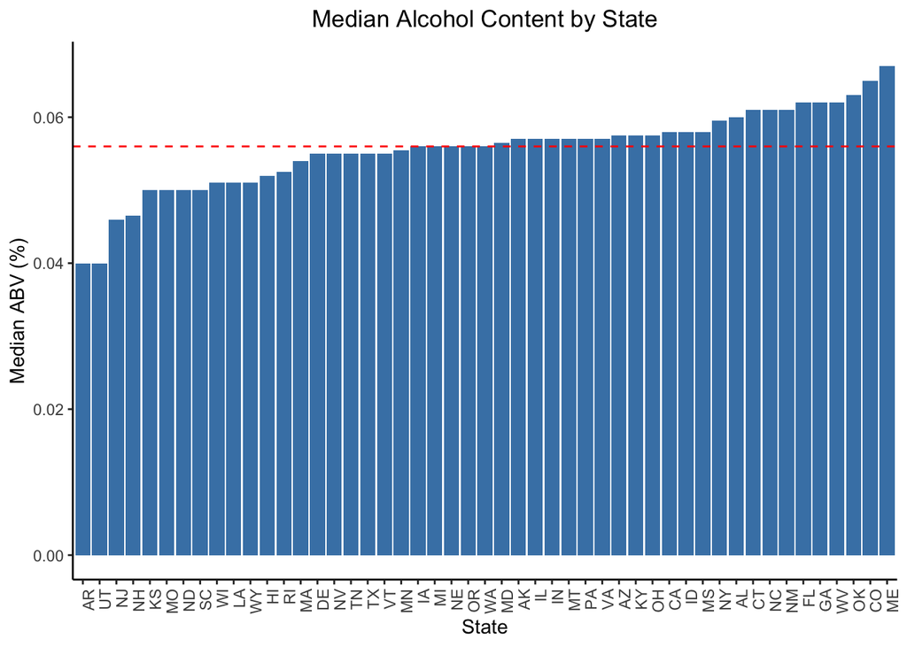

```r
#Groups cleaned data by state and calculates median ABV and IBU
medians_by_state <- cleaned_data %>%
  group_by(State) %>%
  summarise(Median_ABV = median(ABV, na.rm = TRUE),
            Median_IBU = median(IBU, na.rm = TRUE))

#Bar chart displaying the median ABV for each state
ggplot(medians_by_state, aes(x = reorder(State, Median_ABV), y = Median_ABV)) +
  geom_bar(stat = "identity", fill = "steelblue") +
  geom_hline(yintercept = median(medians_by_state$Median_ABV, na.rm = TRUE),
             linetype = "dashed", color = "red") +
  theme_classic() +
  theme(axis.text.x = element_text(angle = 90, hjust = 1)) +
  labs(x = "State", y = "Median ABV (%)", title = "Median Alcohol Content by State") +
  theme(plot.title = element_text(hjust = 0.5))
```

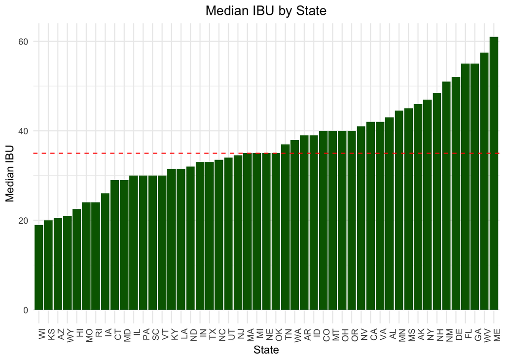

```r
#Bar chart displaying the median IBU for each state
ggplot(medians_by_state, aes(x = reorder(State, Median_IBU), y = Median_IBU)) +
  geom_bar(stat = "identity", fill = "darkgreen") +
  geom_hline(yintercept = median(medians_by_state$Median_IBU, na.rm = TRUE),
             linetype = "dashed", color = "red") +
  theme_minimal() +
  theme(axis.text.x = element_text(angle = 90, hjust = 1)) +
  labs(x = "State", y = "Median IBU", title = "Median IBU by State") +
  theme(plot.title = element_text(hjust = 0.5))
```

#### Which state has the maximum alcoholic (ABV) beer? Which state has the most bitter (IBU) beer?

```r
# Determine which state has the maximum ABV
 state_with_max_ABV <- cleaned_data[which.max(cleaned_data$ABV),]$State
 print(paste("The state with the maximum alcoholic (ABV) beer is", state_with_max_ABV))
```

```
## [1] "The state with the maximum alcoholic (ABV) beer is KY"
```

```r
 # Determine which state has the maximum IBU
state_with_max_IBU <- cleaned_data[which.max(cleaned_data$IBU),]$State
print(paste("The state with the most bitter (IBU) beer is", state_with_max_IBU))
```

```
## [1] "The state with the most bitter (IBU) beer is OR"
```

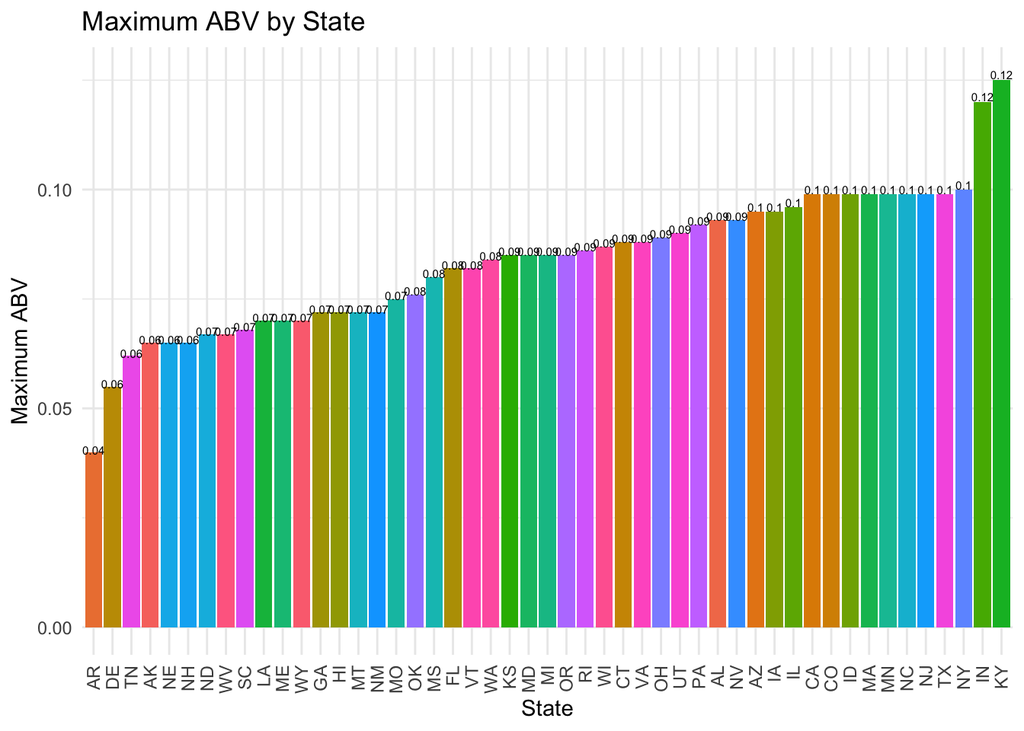

```r
#Calculate max ABV by state
max_abv_by_state <- cleaned_data %>%
  group_by(State) %>%
  summarise(Max_ABV = max(ABV, na.rm = TRUE))

#Calculate max IBU by state
max_ibu_by_state <- cleaned_data %>%
  group_by(State) %>%
  summarise(Max_IBU = max(IBU, na.rm = TRUE))

#Visualizing Maximum ABV by State
ggplot(max_abv_by_state, aes(x = reorder(State, Max_ABV), y = Max_ABV, fill = State)) +
  geom_bar(stat = "identity", show.legend = FALSE) +
  geom_text(aes(label = round(Max_ABV, 2)), position = position_stack(vjust = 1.01), hjust = 0.5, size = 2) +
  theme_minimal() +
  theme(axis.text.x = element_text(angle = 90, vjust = 0.5, hjust = 1)) +
  labs(x = "State", y = "Maximum ABV", title = "Maximum ABV by State")
```

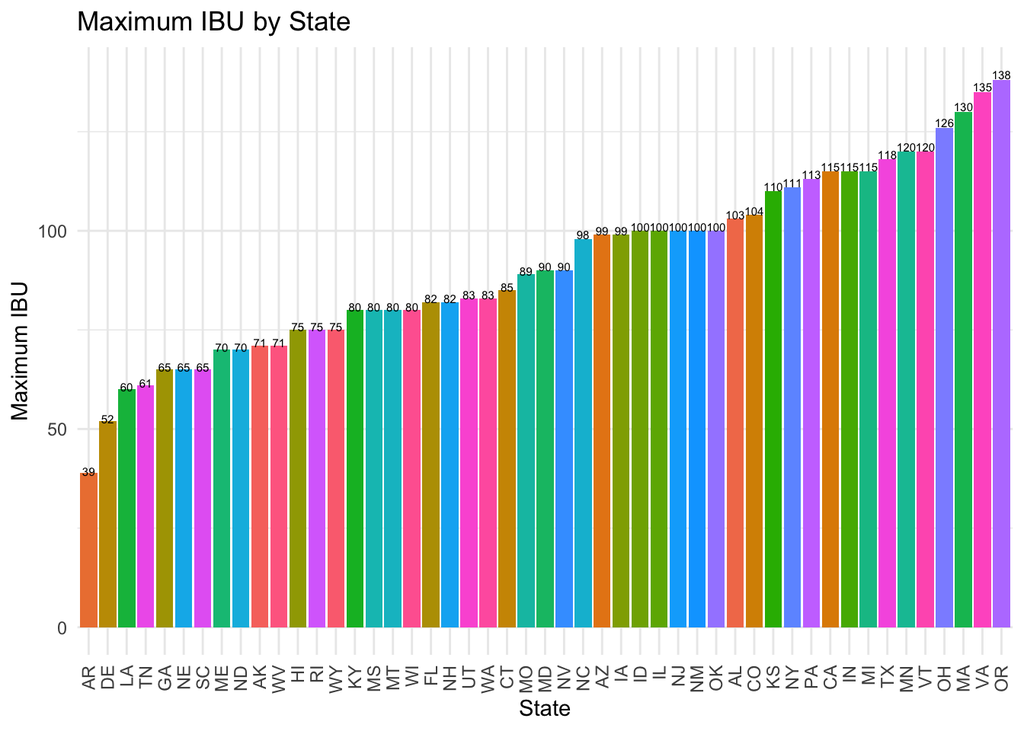

```r
#Visualizing Maximum IBU by State
ggplot(max_ibu_by_state, aes(x = reorder(State, Max_IBU), y = Max_IBU, fill = State)) +
  geom_bar(stat = "identity", show.legend = FALSE) +
  geom_text(aes(label = round(Max_IBU, 2)), position = position_stack(vjust = 1.01), hjust = 0.5, size = 2) +
  theme_minimal() +
  theme(axis.text.x = element_text(angle = 90, vjust = 0.5, hjust = 1)) +
  labs(x = "State", y = "Maximum IBU", title = "Maximum IBU by State")
```

#### The summary statistics and distribution of the ABV variable

Through an analysis of our beer dataset, we’ve identified key insights into the Alcohol by Volume (ABV) and International Bitterness Units (IBU). The ABV ranges from 0.1% to 12.8%, with the majority of beers sitting around 5.6%. However, the average ABV is slightly higher at 5.98%, indicating the presence of some significantly stronger beers. When it comes to bitterness as measured by IBUs, the median value is 35, but the mean is 42.71, showing that some beers have a considerably high bitterness level. A regional analysis highlights Kentucky as the producer of the beer with the highest ABV, while Oregon leads with the most bitter beer. It’s important to note that these findings are based on our current dataset, and may not represent all beers. We also handled missing data points responsibly; specifically, 62 instances where the ABV was not recorded were excluded from the analysis. These insights could be valuable in shaping marketing strategies and understanding regional taste preferences.

#### Is there an apparent relationship between the bitterness of the beer and its alcoholic content? Draw a scatter plot. Make your best judgment of a relationship and EXPLAIN your answer.

The scatter plot below shows the relationship between beer bitterness (IBU) and alcoholic content (ABV) with a linear model fit. From the visualization, we observe a positive slope of the fitted line, indicating a general trend where beers with higher alcoholic content also tend to have higher bitterness levels. This implies a relationship where stronger beers often possess a higher level of bitterness. However, it’s important to note the scatter around the fitted line, indicating variability in this relationship. Some beers with a high ABV might not have very high IBU values and vice versa. This variability could be due to different brewing styles, ingredients, and processes that impact the final ABV and IBU of beer independently.

In summary, while there seems to be a general trend indicating a positive relationship between beer’s alcoholic content and its bitterness, the relationship is not absolute, and exceptions are evident across the dataset. This highlights the complexity of beer brewing, where multiple factors influence the final product’s characteristics.

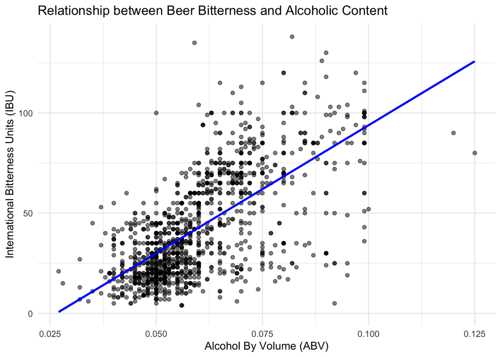

```r
#Scatter plot of relationship between ABV and IBU
ggplot(cleaned_data, aes(x = ABV, y = IBU)) +
  geom_point(alpha = 0.5) +
  theme_minimal() +
  labs(x = "Alcohol By Volume (ABV)",
       y = "International Bitterness Units (IBU)",
       title = "Relationship between Beer Bitterness and Alcoholic Content") +
  geom_smooth(method = "lm", se = FALSE, color = "blue")
```

#### Budweiser would also like to investigate the difference with respect to IBU and ABV between IPAs (India Pale Ales) and other types of Ale (any beer with “Ale” in its name other than IPA). You decide to use KNN classification to investigate this relationship. Provide statistical evidence one way or the other.

To investigate the differences between IPAs AND Ales, we chose to use the KNN classification algorithm to investigate the relationship using the IBU and ABV data points. Here below, you will see the code explained as to how we filtered out the “IPA” and “Other Ale” categories and then ran the KNN function and then set up a confusion matrix. The last function calculates the accuracy of the data and how similar IPAs and Ales are. The functions come up with a percentage accuracy of 83.4% between IPAs and Other Ales based on the IBU and ABV data.

```r
# Prepare the beers dataset
beers <- beers %>%
  filter(grepl("Ale", Style, ignore.case = TRUE) | grepl("IPA", Style, ignore.case = TRUE)) %>%
  mutate(Category = ifelse(grepl("IPA", Style, ignore.case = TRUE), "IPA", "Other Ale"))

# Remove missing values
beers <- na.omit(beers)

# Normalize the data
beers$ABV <- scale(beers$ABV)
beers$IBU <- scale(beers$IBU)

# Prepare the data for the KNN classifier
set.seed(5)
training_index <- sample(1:nrow(beers), 0.8*nrow(beers)) # 80% for training
train <- beers[training_index,]
test <- beers[-training_index,]

# Train the KNN model
knn_model <- knn(train = train[,c('ABV', 'IBU')],
                 test = test[,c('ABV', 'IBU')],
                 cl = train$Category,
                 k = 5)

# Validate the model
knn_table <- table(Predicted = knn_model, Actual = test$Category)
knn_table
```

```
##            Actual
## Predicted   IPA Other Ale
##   IPA        62        14
##   Other Ale  18        99
```

```r
# Calculate the accuracy
accuracy <- sum(knn_model == test$Category) / length(knn_model)
accuracy
```

```
## [1] 0.8341969
```

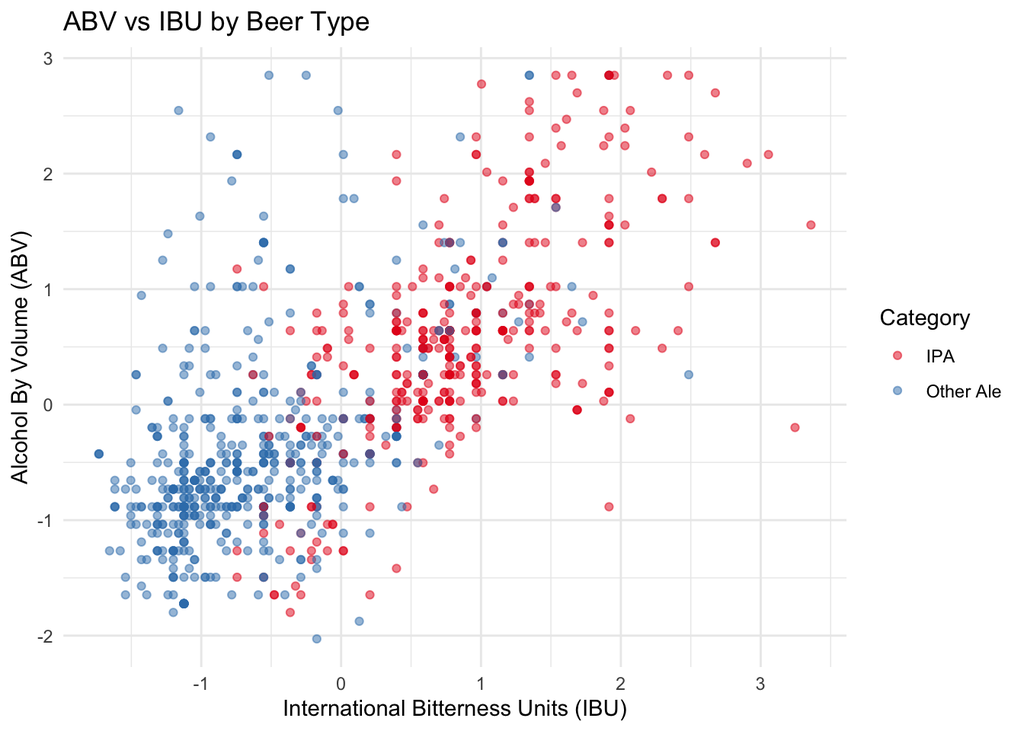

```r
# Scatter plot for ABV vs IBU with color-coding for beer types
ggplot(beers, aes(x = IBU, y = ABV, color = Category)) +
  geom_point(alpha = 0.5) +
  labs(x = "International Bitterness Units (IBU)", y = "Alcohol By Volume (ABV)", title = "ABV vs IBU by Beer Type") +
  theme_minimal() +
  scale_color_brewer(palette = "Set1")
```

#### Find one other useful inference from the data that you feel Budweiser may be able to find value in. You must convince them why it is important and back up your conviction with appropriate statistical evidence.

```r
# Merge the datasets by the common ID fields
merged_data <- merge(beers, breweries, by.x = "Brewery_id", by.y = "Brew_ID")
# Remove rows with missing data
merged_data <- na.omit(merged_data)
# Clean the 'State' column in the merged data by trimming whitespace
merged_data$State <- trimws(merged_data$State)
# Define the market segments based on ABV and IBU
merged_data <- merged_data %>%
  mutate(
    Segment = case_when(
      ABV < 4 & IBU < 21 ~ "Light & Mild",
      ABV >= 4 & ABV <= 6 & IBU >= 21 & IBU <= 50 ~ "Standard & Balanced",
      ABV > 6 & IBU > 50 ~ "Strong & Bitter",
      TRUE ~ "Other"
    )
  )
# Selected states for the analysis
selected_states <- c("KY", "OR")
# Perform the segment analysis only for the selected states
segment_analysis <- merged_data %>%
  filter(State %in% selected_states) %>%
  count(State, Segment) %>%
  group_by(State) %>%
  mutate(Percent = n / sum(n) * 100)
# Print the segment analysis results
print(segment_analysis)
```

```
## # A tibble: 2 × 4
## # Groups:   State [2]
##   State Segment          n Percent
##   <chr> <chr>        <int>   <dbl>
## 1 KY    Light & Mild    10     100
## 2 OR    Light & Mild    69     100
```

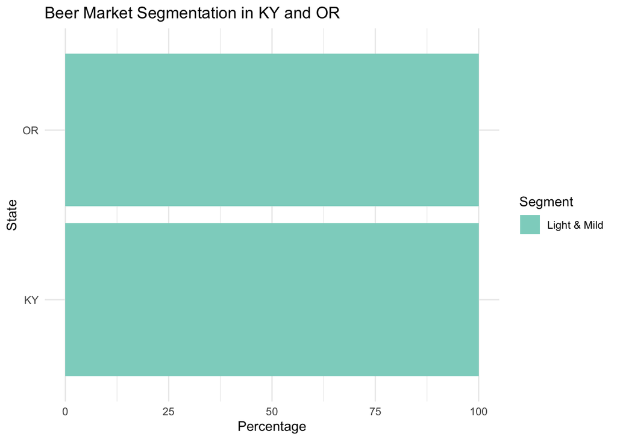

```r
# Plot the segment distribution for the selected states
ggplot(segment_analysis, aes(x = State, y = Percent, fill = Segment)) +
  geom_bar(stat = "identity", position = "dodge") +
  coord_flip() +
  scale_fill_brewer(palette = "Set3") +
  labs(x = "State", y = "Percentage", title = "Beer Market Segmentation in KY and OR") +
  theme_minimal()
```

Looking towards the future, projections indicate an upward trajectory for the beer market. The U.S. beer market is forecasted to grow by 1.98% from 2024 to 20284, and the North American beer market is expected to reach USD 214 billion by 2029, growing at a CAGR of 4.39%5.

Drawing from these statistics and their implications, the evidence would suggest that Budweiser stands to gain by investing in local brands in states such as KY and OR. This approach would not only allow Budweiser to diversify its product portfolio but also position the brand to capitalize on the growing demand for more varied and locally-inspired flavors. In doing so, Budweiser could potentially increase its market share in the evolving U.S. beer industry.